# Preguntas de la base de datos

Jean Paul Yepes

# ¿Cuales son los barrios con mas accidentes?

Como se puede ver en la tabla 1 el barrio con más accidentes con gran diferencia es la Candelaria con 22.374 accidentes desde el 2015 hasta junio del 2020, esto se puede deber a que es la zona más transitada y con más vías, por lo que hace que esta sea una zona que sea más propensa a accidentes que el resto de la ciudad.

Después tenemos a Castilla, Laureles- Estadio, Poblado, Robledo y Belén como las zonas de la ciudad con más de 10.000 accidentes, esto también puede deberse a sus grandes vías, como hay flujo de más vehículos hacen que la probabilidad de accidentes aumenten.

Posteriormente tenemos menos las demás zonas las cuales tienen menos de 10.000 accidentes, hay 2 saltos importantes en esta categoría el salto entre Guayabal y Belén, hay una diferencia alrededor de 3.000 accidentes; la otra es entre Aranjuez y Manrique donde una diferencia de alrededor de 2.000 accidentes; desde este último gran salto los accidentes disminuyen paulatinamente.

Lo que podemos concluir de estos datos es: Candelaria es la zona más accidentada, una hipótesis sobre las zonas con más de 10.000 accidentes tienen es que estas tienen grandes vías lo cual hace que estos sectores sean más propensos a más accidentes, hay 2 grandes saltos en las zonas con menos de 10.000 accidentes habría que caracterizar mejor estas zonas para ver cual es el motivo de estos saltos.

Tabla 1: cantidad de accidentes por barrio

| Zona | Cantidad |
| --- | --- |
| La Candelaria | 22374 |
| Castilla | 14860 |
| Laureles Estadio | 13439 |
| Poblado | 12826 |
| Robledo | 12694 |
| Belén | 11792 |
| Guayabal | 8873 |
| Aranjuez | 7734 |
| Manrique | 5888 |
| Buenos Aires | 5831 |
| La América | 4567 |
| Villa Hermosa | 4022 |
| San Javier | 3048 |
| Doce de octubre | 2789 |
| Popular | 1974 |
| Santa Cruz | 1684 |
| Corregimiento de San Cristóbal | 983 |
| Corregimiento de Santa Elena | 105 |
| Corregimiento de San Sebastián de Palmitas | 84 |

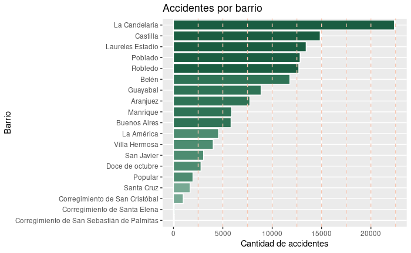

#¿Cuales son las horas con mas accidentes?

Los accidentes aumentan en la entrada a la jornada de trabajo y a la salida de la jornada de trabajo, en la tabla 2 podemos ver los dos picos que ocurren a las 7 de la mañana y a las 5 de la tarde, aunque si comparamos las dos subidas, en la tarde hay casi 600 accidentes más que en la mañana, esto se puede deber que debido al agotamiento después de la jornada laboral hacen que los conductores que sean más propensos a chocar.

Otro dato importante de los datos, es que entre las 9 y a las 11, que son horas laborales hay menos accidentes y despues vuelve a aumentar de nuevo hacia las 12, esto puede ser debido a que entre las 9 y las 11 todos ya están trabajando, por lo que hay menos vehículos rodando que puedan chocar, aunque también podría ser por otra razón que no he considerado porque la cantidad de accidentes debería volver a bajar entre la 1 y 3 de la tarde, pero eso no sucede.

En conclusión, el horario laboral es lo que marca la tendencia a estrellarse, hay una gran diferencia entre las horas laborales y las que no, hay muchos menos accidentes entre las 9 y las 11 que no tiene una buena razón ¿por que a esta hora hay menos accidentes?, a las 5 de la tarde es la hora con más accidentes.

Tabla 2: cantidad de accidentes por hora

| Horas | Cantidad accidentes |
| --- | --- |
| 0 | 1781 |
| 1 | 1120 |
| 2 | 936 |
| 3 | 694 |
| 4 | 1247 |
| 5 | 4248 |
| 6 | 8716 |
| 7 | 9275 |
| 8 | 6557 |
| 9 | 5459 |
| 10 | 5778 |
| 11 | 6245 |
| 12 | 7375 |
| 13 | 7936 |
| 14 | 7711 |
| 15 | 7731 |
| 16 | 8257 |
| 17 | 9853 |
| 18 | 8521 |
| 19 | 7069 |
| 20 | 6452 |
| 21 | 5858 |
| 22 | 4303 |
| 23 | 2445 |

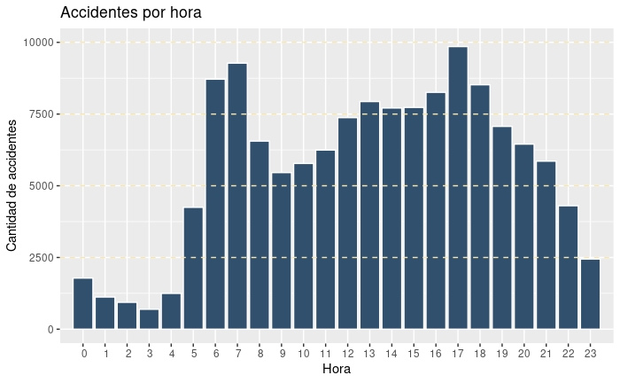

# ¿Como se distribuye los accidentes por meses?

Los meses con menos accidentes son enero, abril, noviembre y diciembre, lo que todos estos meses tienen en común es que son meses con más festivos, en diciembre y enero tenemos la temporada de navidad y el año nuevo, a inicios de abril se da la semana santa y noviembre tiene 2 festivos seguidos, eso explicaría el descenso en los accidentes, para contrastar tenemos febrero que no tiene ningún festivo, que tiene cerca de 1500 accidentes más que otros meses.

Los dos picos de accidentes que ocurren en el año son febrero y julio con cerca de 12300 accidentes, entre 2015 y lo que se registró entre 2020, tocaría caracterizar mejor el mes de julio ya que este mes tiene festivos y aún así presenta una alta accidentalidad.

En conclusión los dos meses más accidentados son febrero y julio, parece que los meses con muchos días festivos son los que marcan que tan propenso se es a sufrir un accidente.

Tabla 3: cantidad de accidentes por mes

| Horas | Cantidad accidentes |
| --- | --- |
| 1 | 10858 |
| 2 | 12343 |
| 3 | 11462 |
| 4 | 10408 |
| 5 | 11825 |
| 6 | 11467 |
| 7 | 12297 |
| 8 | 11775 |
| 9 | 11347 |
| 10 | 11060 |
| 11 | 10318 |
| 12 | 10407 |

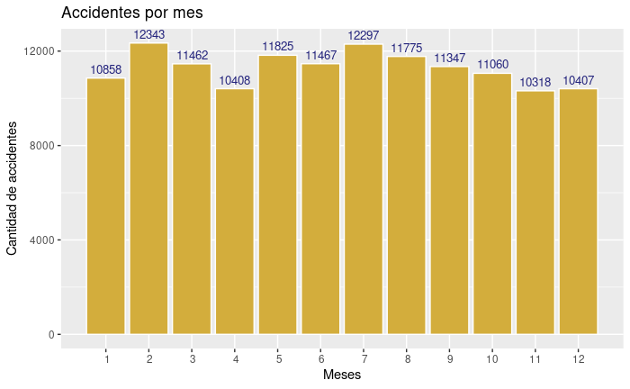

#¿Cuales fueron las clases de accidentes mas comunes?

Las clases de accidentes más comunes son choque y otro, habría qué profundizar en que tipos de accidentes son otros, para obtener más información, pero por una gran diferencia los choques son la clase de accidente más común (un 54% de los accidentes son choques).

También hay una gran cantidad de atropellos contra los motociclistas, un 9% de los accidentes son por este motivo, también tocaría buscar los motivos por los cuales los motociclistas son atropellados ¿son imprudentes? ¿los conductores son imprudentes? ¿no los ven?

La clase de accidente más común es choque, los atropellos son un 9% de las clases de accidentes tocaría indagar más en las causas de estos.

Tabla 4: clases de accidentes

| Horas | Cantidad accidentes |
| --- | --- |
| Choque | 73390 |
| Otro | 23932 |
| Caida Ocupante | 17386 |
| Atropello | 12640 |
| Volcamiento | 8207 |
| Incendio | 9 |
|  | 3 |

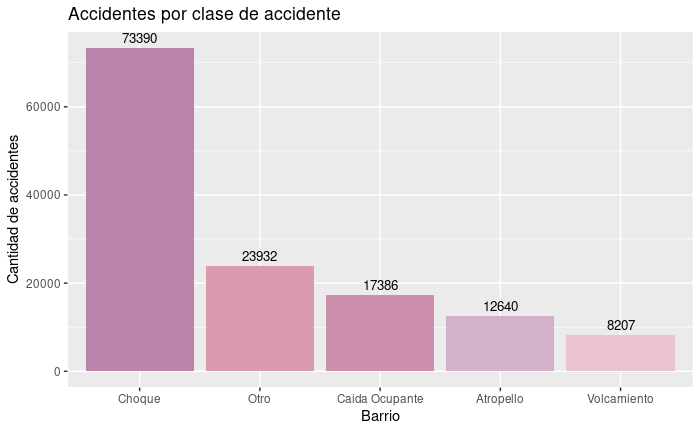

# Comparacion gravedad de accidentes por año

El 2016, 2017 y 2019 son los años más accidentados, a unque en el periodo de 2016-2018 pareciera que existía una tendencia a la baja en los accidentes, eso no continuo en el año 2019 donde vuelve a llegar otro pico de accidentes, en ese mismo periodo hubo una variación de los heridos, pero se observa que la cantidad de daños es similar todos los años.

Un balance positivo de los datos es que a pesar de la variación en la cantidad de accidentes la cantidad de muertos no supera los 100, lo cual es algo positivo ya que este grupo es menos del 1% de los accidentes.

En conclusión entre 2016-2018 pareciera que la accidentalidad iba a bajar pero esa tendencia se contradijo con lo sucedido en 2019, afortunadamente los muertos y los daños no parecen aumentar mucho a lo largo de los años, lo que hace la diferencia entre la cantidad de accidentes son los heridos.

Tabla 5: Gravedad de accidentes por año

|  | HERIDO | MUERTO | SOLO DAÑOS |
| --- | --- | --- | --- |
| 2015 | 18501 | 74 | 4439 |
| 2016 | 21222 | 84 | 5191 |
| 2017 | 20577 | 100 | 5253 |
| 2018 | 18410 | 85 | 5154 |
| 2019 | 20281 | 96 | 5432 |
| 2020 | 8726 | 59 | 1883 |

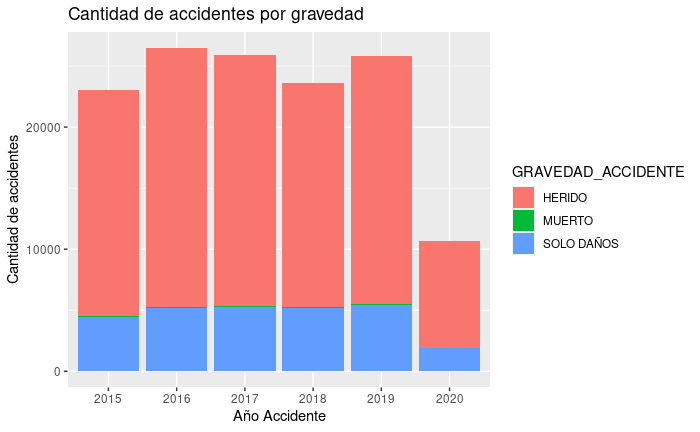

# ¿Cómo se distribuye los accidentes diseño vía?

Los lugares donde ocurre la mayor cantidad de accidentes es por tramo de vía, esto como podemos ver es compatible con lo que se mencionó sobre las zonas con mayor número de accidentes, estas zonas se caracterizan por tener grandes vías, que es donde suelen ocurrir los accidentes.

Algo sorprendente de los datos es que la intersección y los lotes tienen una cantidad de accidentes parecida, se esperaría que en los lotes no existieran tantos accidentes pero los datos nos dicen lo contrario, ir por una intersección es tan accidentado como en un lote. Otra cosa que yo no me esperaba es que las glorietas no tienen tantos accidentes, en realidad estas vías son de lo más seguras.

En conclusión las vías son las rutas más peligrosas, las intersecciones son tan peligrosas como los lotes y las glorietas son vías más seguras.

Tabla 6 accidentes por tipo de vía

| Diseño vía | Numero de accidentes |
| --- | --- |
| Tramo de via | 88865 |
| Interseccion | 22771 |
| Lote o Predio | 19109 |
| Glorieta | 2471 |
| Paso Elevado | 786 |
| Puente | 571 |
| Ciclo Ruta | 442 |
| Paso Inferior | 415 |
| Paso a Nivel | 56 |
| Tunel | 39 |
| Via peatonal | 24 |
| Pontón | 18 |

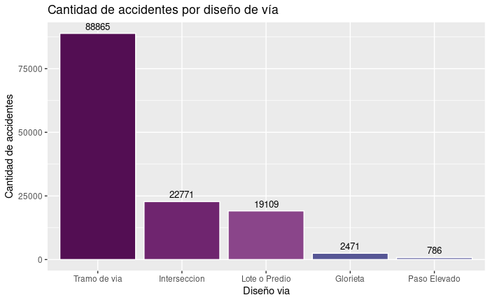

# Recomendaciones

Para la recolección de los datos sería ideal estandarizar un formato para las fechas, debido a que esto puede ser un campo que se presta para muchas inconsistencias, que existan otras categorías para clasificar las clases de accidente, debería averiguarse como se puede subdividir la categoría otros para obtener más información de los datos.

También sería deseable que los accidentes se pusieran las coordenadas de donde ocurrieron, ya que la ubicación por zonas o direcciones a veces se presta para inconsistencias, con la toma de coordenadas se podría mejorar la calidad de esta información.

Se pueden tomar medidas para reducir la accidentalidad, debería haber un control más estricto de las vías principales en las horas que todos entran a trabajar, debido a que es el momento y lugares donde más accidentes ocurren en la ciudad, garantizando un mejor control de las zonas, se reduciría los accidentes y ayudaría a mejorar el tráfico.

# Conclusiones

Se pueden tomar medidas correctivas en la ciudad para prevenir la accidentalidad, se identifica que las vías son los lugares con mayor accidentalidad, sobre todo en la zona centro a las 7 de la mañana y 5 de la tarde, que son los momentos donde ocurren la mayor cantidad de accidentes; haciendo un control de las medidas de seguridad a esas horas se podría mejorar la accidentalidad en la zona de extras se pueden encontrar algunos puntos que en los que se debería hacer control.

Un balance positivo es que a pesar de que la mayoría de accidentes los motociclistas terminan heridos, hay muy pocos casos en donde mueren, lo cual indica que algo se está haciendo bien, ya que la proporción de los que terminan muertos es del menos del 1%.

# Extra

## Mapas sobre la accidentalidad

Tenemos dos mapas, en el primero tenemos los 100 puntos donde ocurren más accidentes, en el segundo tenemos los 500 puntos donde ocurren más accidentes; los 100 primeros ocupan 38.300 accidentes y los 500 primeros ocupan 115.312 accidentes (el 85% de los datos). Las gráficas también indican los lugares con más frecuencia.

Podemos ver en el mapa con los 100 puntos con más accidentes que hay una tendencia clara a que los accidentes ocurran en la regional, cosa que nos ayuda a ver que la conclusión de que los accidentes ocurren en las grandes vías parece cierta, además de que gran parte se concentran por el centro de la ciudad por el punto azul claro que se ve al lado del cerro el volador.

De los 500 lugares con más accidentes podemos ver que la vía paralela por la 80 también capta gran cantidad de los accidentes junto con la carrera 43, esta tendencia se empezó a dibujar con las primeras coordenadas y se aumenta en este mapa, aunque inevitablemente la que más accidentes se lleva es la avenida regional especialmente en el centro, otra cosa que vale la pena ver, son los puntos dispersos en el mapa que no necesariamente están en la regional o en la 80, estos también pueden ser puntos estratégicos para reducir los accidentes.

En conclusión el mapa de los 100 puntos donde ocurren más accidentes, podría indicar los lugares donde se podría empezar a controlar la accidentalidad, ya que estos son donde se concentran buena parte de los accidentes y los 500 puntos (donde se concentran el 85% de los datos) muestran claramente las tendencias de los accidentes que son la regional, la 80 y la 43.

### Los 100 lugares con mas accidentes

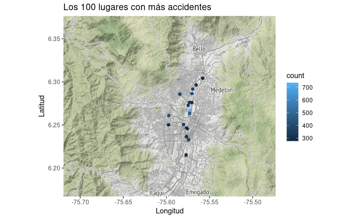

```
[1] "La cantidad de accidentes en el mapa 1 son: 38300"
```

### Los 500 lugares con mas accidentes

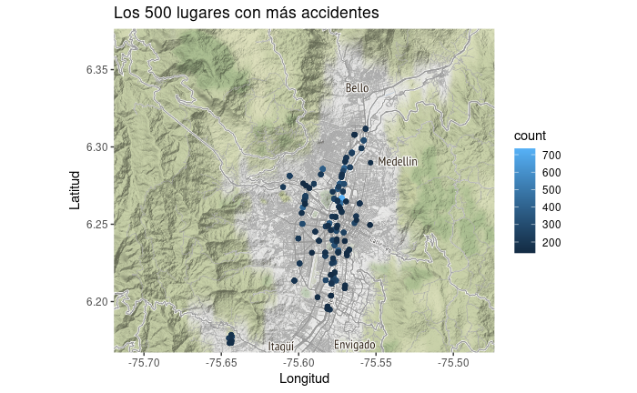

```
[1] "La cantidad de accidentes en el mapa anterior son: 115312"
```